# Vnedor Log Analysis - Clutering Costomers Using Unsupervised Machine Learning

Shigeki Kamata 2020/09/29

# Table of Contents

## Introduction

Let's say you are an analyst at a company that provides various online services in the form of sending data at the request of the clients. The company receives millions of online requests and the transaction log is stored in the company’s database. You are given a sample vendor log for a specific month and are asked to gain some insights about the customers, products and transactions. The stakeholders might be wondering which products were successful and how the volume of transactions changes based on the day. They also might be wondering whether there are some behavioral tendencies for each customer and if they can create a new sales plan based on those tendencies. As an analyst, your job is to answer those questions using statistics and machine learning algorithms.  
In this article I will attempt to analyze the behaviors of each customer based on the information provided by the vendor log. The analysis consists of two parts. The first part studies the overall characteristics of the data set using basic statistical information and visualization. The second part focuses on customer-specific behaviors. This part has two sections. First, I took a closer look at the behaviors of the top three customers, which makes up 60% of the total transaction activity. Then I attempted to divide the customers into clusters based on their March 2020 behaviors and study the characteristics of each cluster. I utilized two unsupervised machine learning algorithms (K-means and Hierarchical Clustering) to conduct this cluster analysis.

## Basic Analysis

### Data Preparation

First, we'll need to import the necessary library and load the data file below:

```python
# Import the libraries
import numpy as np
import matplotlib.pyplot as plt
import pandas as pd
pd.set_option('display.max_rows', 500)
pd.set_option('display.max_columns', 500)
```

```python
# Load the dataset
df = pd.read_csv('VendorLogs-raw_202003_copy.txt', sep = "\t", header = None)
# Name columns
df.columns = ['Date', 'CustID', 'TFound', 'TCount',
              'TDetail', 'TResult', 'TType']
# Limit the data to March of 2020
df = df.loc[(df['Date'] >= 20200301) & (df['Date'] <= 20200331)]
```

The following columns are located in the data set:  
Date  
CustID  
TFound: How the request was handled; 0=unknown, 1=find, 2=not find, 3=not find filtered, 4=error and so on  
TCount: The number of service transaction processed  
TDetail: The detail of request  
TResult: The result of each request  
TType: The type of transaction  
Next, let's take a look at the data set below:

```python
df.head(10)
```

|  | Date | CustID | TFound | TCount | TDetail | TResult | TType |
| --- | --- | --- | --- | --- | --- | --- | --- |
| 0 | 20200301 | 1932 | 1 | 1 | 4012(2310,120,120,122),4030(1710,211) | 1(1,1,1,1),1(2,1) | RT:r |
| 1 | 20200301 | 2024 | 0 | 0 | 4030(1710,211,478,2805) | 2(2,2,2,2) | RT:r |
| 2 | 20200301 | 1980 | 0 | 0 | 4012(2310,601,120,122),4030(1710,211,2805) | 1(5,1,1,1),2(2,2,2) | RT:r |
| 3 | 20200301 | 1932 | 1 | 1 | 4012(2310,120,120,122),4030(1710,211) | 1(1,1,1,1),1(2,1) | RT:r |
| 4 | 20200301 | 1980 | 1 | 1 | 4012(2310,120,122),4030(1710,211) | 1(1,1,1),1(2,1) | RT:r |
| 5 | 20200301 | 1980 | 1 | 1 | 4012(2310,120,122),4030(1710,211) | 1(1,1,1),1(2,1) | RT:r |
| 6 | 20200301 | 1980 | 1 | 1 | 4012(2310,120,122),4030(1710,211,2805) | 1(1,1,1),1(2,2,1) | RT:r |
| 7 | 20200301 | 2024 | 0 | 0 | 4030(1710,211,478,2805) | 2(2,2,2,2) | RT:r |
| 8 | 20200301 | 1932 | 1 | 1 | 4012(2310,120,120,122),4030(1710,211) | 1(1,1,1,1),1(2,1) | RT:r |
| 9 | 20200301 | 1980 | 1 | 1 | 4012(2310,120,120,122),4030(1710,211) | 1(1,1,1,1),1(2,1) | RT:r |

In order to decipher if there is a day-of-the-week-related pattern in the transaction activity, let's append a day column to the data:

```python
# Append day of week to df
from datetime import date
import calendar

def get_day_of_week(timestamp):
    year = int(timestamp / 10000)
    month =  int((timestamp / 100) % 100)
    day =  int(timestamp % 100)
    mydate = date(year, month, day)
    return calendar.day_name[mydate.weekday()]
day = df['Date'].map(get_day_of_week)
df.insert(loc=1, column='Day', value=day )
df.head(10)
```

|  | Date | Day | CustID | TFound | TCount | TDetail | TResult | TType |
| --- | --- | --- | --- | --- | --- | --- | --- | --- |
| 0 | 20200301 | Sunday | 1932 | 1 | 1 | 4012(2310,120,120,122),4030(1710,211) | 1(1,1,1,1),1(2,1) | RT:r |
| 1 | 20200301 | Sunday | 2024 | 0 | 0 | 4030(1710,211,478,2805) | 2(2,2,2,2) | RT:r |
| 2 | 20200301 | Sunday | 1980 | 0 | 0 | 4012(2310,601,120,122),4030(1710,211,2805) | 1(5,1,1,1),2(2,2,2) | RT:r |
| 3 | 20200301 | Sunday | 1932 | 1 | 1 | 4012(2310,120,120,122),4030(1710,211) | 1(1,1,1,1),1(2,1) | RT:r |
| 4 | 20200301 | Sunday | 1980 | 1 | 1 | 4012(2310,120,122),4030(1710,211) | 1(1,1,1),1(2,1) | RT:r |
| 5 | 20200301 | Sunday | 1980 | 1 | 1 | 4012(2310,120,122),4030(1710,211) | 1(1,1,1),1(2,1) | RT:r |
| 6 | 20200301 | Sunday | 1980 | 1 | 1 | 4012(2310,120,122),4030(1710,211,2805) | 1(1,1,1),1(2,2,1) | RT:r |
| 7 | 20200301 | Sunday | 2024 | 0 | 0 | 4030(1710,211,478,2805) | 2(2,2,2,2) | RT:r |
| 8 | 20200301 | Sunday | 1932 | 1 | 1 | 4012(2310,120,120,122),4030(1710,211) | 1(1,1,1,1),1(2,1) | RT:r |
| 9 | 20200301 | Sunday | 1980 | 1 | 1 | 4012(2310,120,120,122),4030(1710,211) | 1(1,1,1,1),1(2,1) | RT:r |

Next, we'll check for any null data:

```python
df.isnull().sum()
```

```
Date            0
Day             0
CustID          0
TFound          0
TCount          0
TDetail    607244
TResult    607244
TType           0
dtype: int64
```

```python
df[df['TDetail'].isnull()]
```

|  | Date | Day | CustID | TFound | TCount | TDetail | TResult | TType |
| --- | --- | --- | --- | --- | --- | --- | --- | --- |
| 3463336 | 20200303 | Tuesday | 2169 | 0 | 0 | NaN | NaN | RP:f |
| 3464317 | 20200304 | Wednesday | 2169 | 0 | 0 | NaN | NaN | RP:f |
| 3464318 | 20200304 | Wednesday | 2169 | 0 | 0 | NaN | NaN | RP:f |
| 3464319 | 20200304 | Wednesday | 2169 | 0 | 0 | NaN | NaN | RP:f |
| 3465319 | 20200304 | Wednesday | 2169 | 0 | 0 | NaN | NaN | RP:f |
| ... | ... | ... | ... | ... | ... | ... | ... | ... |
| 9084126 | 20200331 | Tuesday | 2707 | 0 | 0 | NaN | NaN | RS:b |
| 9084299 | 20200331 | Tuesday | 2707 | 0 | 0 | NaN | NaN | RS:b |
| 9087922 | 20200331 | Tuesday | 2707 | 0 | 0 | NaN | NaN | RS:b |
| 9089062 | 20200331 | Tuesday | 2707 | 0 | 0 | NaN | NaN | RS:b |
| 9089825 | 20200331 | Tuesday | 2707 | 0 | 0 | NaN | NaN | RS:b |

607244 rows × 8 columns

Based on these results, it looks like TDetail and TResult get NaN when TCount is 0, which makes sense because no transaction detail can be added if the requested data was not found.

Next, let's observe some basic statistics for each column:

```
Date
count      9056295
unique          31
top       20200323
freq        551459
Name: Date, dtype: object
Unique values:
['20200301' '20200302' '20200303' '20200304' '20200305' '20200306'
 '20200307' '20200308' '20200309' '20200310' '20200311' '20200312'
 '20200313' '20200314' '20200315' '20200316' '20200317' '20200318'
 '20200319' '20200320' '20200321' '20200322' '20200323' '20200324'
 '20200325' '20200326' '20200327' '20200328' '20200329' '20200330'
 '20200331']
```

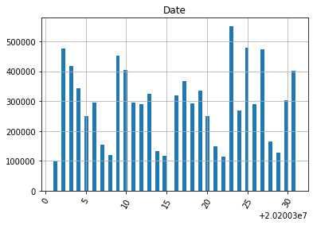

```
-----------------------------------------------------------------------------------
Day
count     9056295
unique          7
top        Monday
freq      2105881
Name: Day, dtype: object
Unique values:
['Sunday' 'Monday' 'Tuesday' 'Wednesday' 'Thursday' 'Friday' 'Saturday']
```

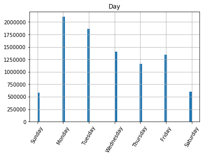

```
-----------------------------------------------------------------------------------
CustID
count     9056295
unique         91
top          2204
freq      2634629
Name: CustID, dtype: object
Unique values:
['1932' '2024' '1980' '2184' '2159' '2070' '2117' '2180' '2204' '2056'
 '2216' '2080' '1927' '2223' '1587' '1628' '1751' '1596' '1752' '260'
 '198' '1655' '1585' '1603' '1653' '1654' '1563' '1734' '2169' '1793'
 '1287' '1675' '1692' '1794' '1569' '1661' '1920' '1967' '2071' '1634'
 '1507' '1010' '2669' '2276' '2493' '2662' '1054' '1' '2413' '2424' '2520'
 '1717' '2187' '2509' '1768' '1095' '2704' '2707' '2362' '1749' '2282'
 '2046' '1885' '1923' '2537' '1021' '2623' '2197' '1173' '2684' '2310'
 '1017' '1285' '2343' '2382' '2507' '2680' '2588' '1052' '2574' '2245'
 '1074' '1966' '1018' '1205' '2256' '2593' '2481' '2405' '2498' '2633']
```

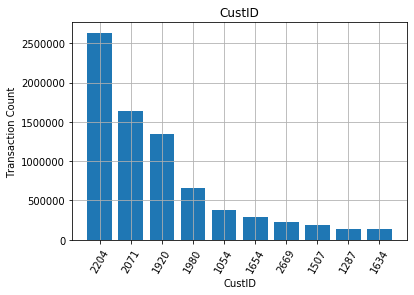

```
-----------------------------------------------------------------------------------
TFound
count     9056295
unique       1958
top             1
freq      6643888
Name: TFound, dtype: object
Unique values:
['1' '0' '1186' ... '41107' '6801' '54685']
```

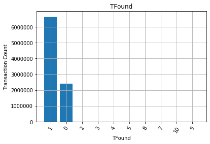

```
-----------------------------------------------------------------------------------
TCount
count     9056295
unique         32
top             1
freq      6517639
Name: TCount, dtype: object
Unique values:
['1' '0' '7' '3' '2' '5' '10' '4' '22' '16' '8' '6' '9' '17' '14' '12'
 '11' '24' '18' '28' '15' '13' '21' '30' '20' '27' '26' '19' '23' '25'
 '29' '50']
```

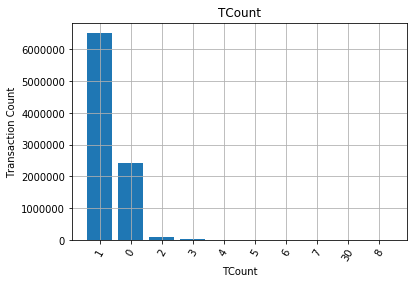

```
-----------------------------------------------------------------------------------
TType
count     9056295
unique         11
top          RT:t
freq      2746296
Name: TType, dtype: object
Unique values:
['RT:r' 'RT:s' 'RT:t' 'RP:c' 'RP:f' 'RP:i' 'RP:r' 'RP:t' 'RP:v' 'RS:b'
 'BT:p']
```

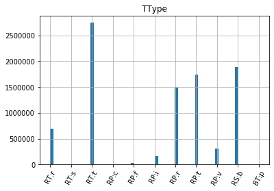

```python
for col in ['Date', 'Day', 'CustID', 'TFound', 'TCount', 'TType']:
    print(col)
    print(df[col].astype(str).describe())
    print('Unique values:')
    print(df[col].astype(str).unique())
    # Plot Histogram
    if col in ['Date', 'Day', 'TType']:
        plt.hist(df[col], bins = 62 )
        plt.xticks(rotation=60)
        plt.title(col)
        plt.grid(True)
        plt.show()
    if col in ['CustID', 'TFound', 'TCount']:
        plot_data = df.groupby(col).Date.count().sort_values(axis = 0, ascending = False)
        plot_data = plot_data.head(10)
        plt.bar(plot_data.index.astype(str) , plot_data )
        plt.title(col)
        plt.xticks(rotation=60)
        plt.xlabel(col)
        plt.ylabel('Transaction Count')
        plt.grid(True)
        plt.show()
    print("-----------------------------------------------------------------------------------")
```

Our set defined values for TFound include the following: 0=unknown, 1=find, 2=no find, 3=no find filtered, 4=error, 5=timeout and 6=not completed  
Since TFound doesn't exist within these set values, we can convert the TFound undefined values to 0 (=unknown).

```python
# Find undefined TFound Value and replace with zeros
illigal_values = list(df.loc[(df.TFound < 0) | (df.TFound > 6)].TFound)
df.TFound = df.TFound.replace(to_replace= illigal_values, value = 0)
```

Let's take a look at the unique values in the TFound column again:

```python
# Check the result
list(df.TFound.unique())
```

```
[1, 0, 2, 4, 3, 6, 5]
```

## CustID-wise Analysis

In this next section, we will attempt to divide the customers in this sameple into groups based on their behaviors in the month. In order to archive this, we will utilize two unsupervised machine learning algorithms: K-means and Hierarchical Clustering. We will review the basic methodologies of these algorithms as we apply them to the data set below.

### Data Preparation

```python
# Import the dataset and add columns
df = pd.read_csv('VendorLogs_custwise.csv')
df['TotalRequest'] = df.iloc[:,33:40].apply(lambda row: sum(row), axis =1)
df['Percentage'] = df['TotalRequest'].apply(lambda value: str(round(value / df['TotalRequest'].sum() * 100, 1)) + " %")
col_names = list(df.columns)
col_names[0] = 'CustID'
df.columns = col_names
df.head(10)
```

|  | CustID | TCount | 20200301 | 20200302 | 20200303 | 20200304 | 20200305 | 20200306 | 20200307 | 20200308 | 20200309 | 20200310 | 20200311 | 20200312 | 20200313 | 20200314 | 20200315 | 20200316 | 20200317 | 20200318 | 20200319 | 20200320 | 20200321 | 20200322 | 20200323 | 20200324 | 20200325 | 20200326 | 20200327 | … |
| --- | --- | --- | --- | --- | --- | --- | --- | --- | --- | --- | --- | --- | --- | --- | --- | --- | --- | --- | --- | --- | --- | --- | --- | --- | --- | --- | --- | --- | --- | --- |
| 0 | 1 | 49595 | 0 | 0 | 80 | 0 | 2 | 0 | 0 | 0 | 2 | 2 | 0 | 0 | 0 | 0 | 0 | 1214 | 0 | 0 | 0 | 0 | 0 | 0 | 0 | 255 | 2 | 4 | 50241 | … |
| 1 | 198 | 39 | 0 | 0 | 2 | 0 | 0 | 5 | 9 | 0 | 1 | 1 | 0 | 4 | 0 | 0 | 0 | 0 | 1 | 0 | 3 | 0 | 0 | 0 | 0 | 0 | 2 | 2 | 0 | … |
| 2 | 260 | 31 | 0 | 4 | 0 | 0 | 0 | 5 | 0 | 0 | 0 | 2 | 0 | 0 | 4 | 0 | 0 | 0 | 1 | 2 | 0 | 0 | 0 | 0 | 5 | 7 | 8 | 21 | 6 | … |
| 3 | 1010 | 48098 | 0 | 16671 | 0 | 0 | 0 | 18681 | 0 | 0 | 0 | 1400 | 0 | 0 | 0 | 0 | 0 | 0 | 0 | 0 | 0 | 12 | 0 | 0 | 0 | 0 | 0 | 0 | 0 | … |
| 4 | 1017 | 104 | 0 | 0 | 4 | 0 | 24 | 8 | 0 | 0 | 0 | 16 | 4 | 4 | 0 | 0 | 0 | 8 | 0 | 4 | 0 | 0 | 0 | 0 | 0 | 0 | 0 | 8 | 0 | … |
| 5 | 1018 | 9 | 0 | 0 | 0 | 0 | 0 | 0 | 0 | 0 | 0 | 0 | 0 | 0 | 0 | 0 | 0 | 2 | 2 | 0 | 0 | 0 | 0 | 0 | 0 | 0 | 0 | 0 | 0 | … |
| 6 | 1021 | 36 | 0 | 12 | 0 | 0 | 0 | 0 | 0 | 0 | 0 | 0 | 12 | 0 | 0 | 0 | 0 | 0 | 0 | 0 | 0 | 0 | 0 | 0 | 0 | 0 | 0 | 0 | 0 | … |
| 7 | 1052 | 29 | 0 | 0 | 0 | 0 | 0 | 4 | 0 | 0 | 0 | 0 | 0 | 4 | 0 | 0 | 0 | 0 | 0 | 0 | 0 | 0 | 0 | 0 | 4 | 0 | 0 | 8 | 0 | … |
| 8 | 1054 | 332442 | 0 | 40531 | 0 | 0 | 0 | 0 | 0 | 0 | 19653 | 0 | 0 | 0 | 0 | 0 | 0 | 0 | 0 | 0 | 38867 | 0 | 0 | 0 | 274576 | 0 | 0 | 0 | 0 | … |
| 9 | 1074 | 6 | 0 | 0 | 0 | 0 | 0 | 0 | 0 | 0 | 0 | 4 | 0 | 0 | 0 | 0 | 0 | 0 | 0 | 0 | 0 | 0 | 0 | 0 | 0 | 0 | 0 | 0 | 0 | … |

### Top 3 Customers

As we saw in the previous part, approximately 60% of the total transactions are requested by the one of the top three customers. Hence, it is worth observing their behaviors individually.

```python
top_cust = df.sort_values(by=['TotalRequest'], ascending=False).iloc[:,[0,-2,-1]].head(10)
top_cust
```

|  | CustID | TotalRequest | Percentage |
| --- | --- | --- | --- |
| 59 | 2204 | 2634629 | 29.1 % |
| 50 | 2071 | 1639529 | 18.1 % |
| 39 | 1920 | 1347440 | 14.9 % |
| 45 | 1980 | 659262 | 7.3 % |
| 8 | 1054 | 373627 | 4.1 % |
| 25 | 1654 | 288305 | 3.2 % |
| 86 | 2669 | 225406 | 2.5 % |
| 15 | 1507 | 181421 | 2.0 % |
| 14 | 1287 | 132346 | 1.5 % |
| 23 | 1634 | 132342 | 1.5 % |

```
CustID: 2204
```

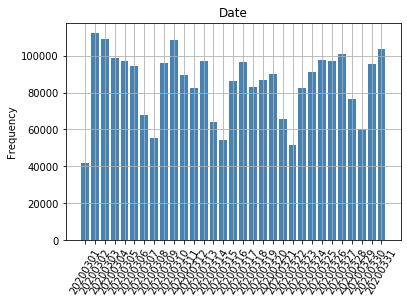

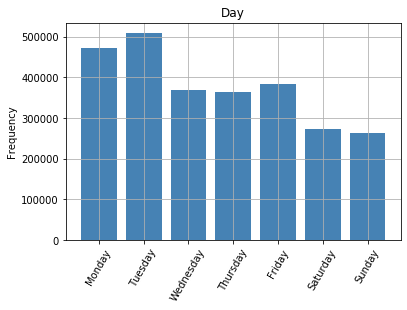

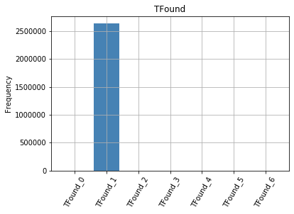

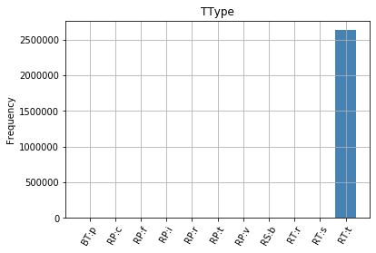

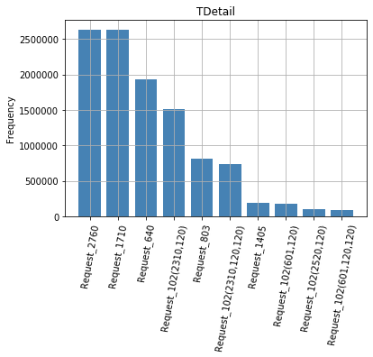

```
CustID: 2071
```

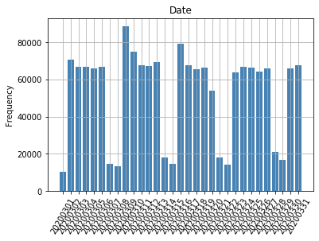

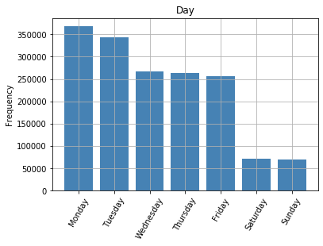

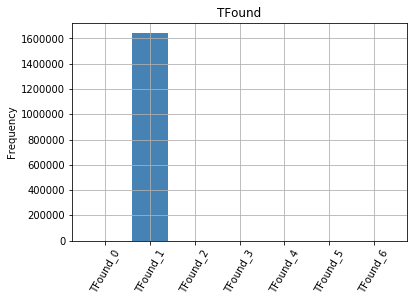

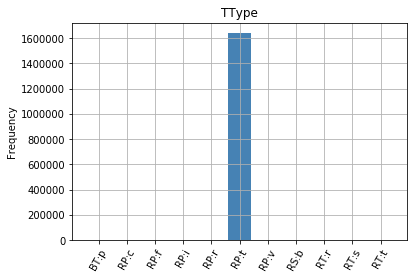

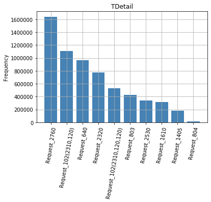

```
CustID: 1920
```

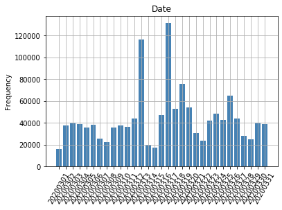

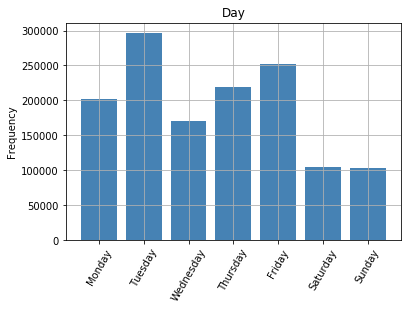

[3 more figures not shown]

```python
categories = {'Date': list(df.columns[2:33]),'Day': list(df.columns[33:40]),
              'TFound': list(df.columns[40:47]),'TType': list(df.columns[47:58]),
             'TDetail': list(df.columns[58:205])}
top_custid = top_cust['CustID'].head(3).tolist()

for i in range(len(top_custid)):
    print('CustID: ' + str(top_custid[i]))
    for key in categories:
        if key != 'TDetail':
            plt.bar(categories[key],
                   df[categories[key]].loc[df.CustID == top_custid[i]].values.tolist()[0],
                    color='steelblue')
            plt.xticks(rotation=60)
            plt.ylabel('Frequency')
            plt.title(key)
            plt.grid(True)
            plt.show()
        else:
            row = df[categories[key]].loc[df.CustID == top_custid[i]]
            row = row.sort_values(by = row.index[0],axis=1, ascending=False, inplace=False, kind='quicksort', na_position='last')
            plt.bar(row.columns[0:10],row.iloc[0,0:10],color='steelblue')
            plt.xticks(rotation=80)
            plt.title(key)
            plt.ylabel('Frequency')
            plt.grid(True)
            plt.show()
```

### Clustering the Customers into Groups Using Machine Learning

Now we will attempt to divide the data set into groups using unsupervised machine learning algorithms. We are going to use the following columns for this clustering analysis:

Date  
Day  
TFound  
TType  
TDetail

Since the total request counts vary vastly depending on the customer, we need to scale the data so that each data has an equal impact on the final clustering result. To do this we will take each row value and divide it by the total number of March transactions for that customer. This way we are able to convert the count of each entity into a percentage-based ratio for each customer. Below is the scaled data set:

```python
scaled_df = df.iloc[:,2:-2].apply(lambda row: row / (df['TotalRequest'] + 1), axis = 0)
scaled_df.head(10)
```

|  | 20200301 | 20200302 | 20200303 | 20200304 | 20200305 | 20200306 | 20200307 | 20200308 | 20200309 | 20200310 | 20200311 | 20200312 | 20200313 | 20200314 | 20200315 | 20200316 | 20200317 | 20200318 | 20200319 | 20200320 | 20200321 | 20200322 | 20200323 | 20200324 | 20200325 | 20200326 | 20200327 | 20200328 | 20200329 | … |
| --- | --- | --- | --- | --- | --- | --- | --- | --- | --- | --- | --- | --- | --- | --- | --- | --- | --- | --- | --- | --- | --- | --- | --- | --- | --- | --- | --- | --- | --- | --- |
| 0 | 0.0 | 0.000000 | 0.000859 | 0.0 | 0.000021 | 0.000000 | 0.00000 | 0.0 | 0.000021 | 0.000021 | 0.000000 | 0.000000 | 0.000000 | 0.0 | 0.0 | 0.013033 | 0.000000 | 0.000000 | 0.000000 | 0.000000 | 0.0 | 0.0 | 0.000000 | 0.002738 | 0.000021 | 0.000043 | 0.539379 | 0.0 | 0.0 | … |
| 1 | 0.0 | 0.000000 | 0.062500 | 0.0 | 0.000000 | 0.156250 | 0.28125 | 0.0 | 0.031250 | 0.031250 | 0.000000 | 0.125000 | 0.000000 | 0.0 | 0.0 | 0.000000 | 0.031250 | 0.000000 | 0.093750 | 0.000000 | 0.0 | 0.0 | 0.000000 | 0.000000 | 0.062500 | 0.062500 | 0.000000 | 0.0 | 0.0 | … |
| 2 | 0.0 | 0.060606 | 0.000000 | 0.0 | 0.000000 | 0.075758 | 0.00000 | 0.0 | 0.000000 | 0.030303 | 0.000000 | 0.000000 | 0.060606 | 0.0 | 0.0 | 0.000000 | 0.015152 | 0.030303 | 0.000000 | 0.000000 | 0.0 | 0.0 | 0.075758 | 0.106061 | 0.121212 | 0.318182 | 0.090909 | 0.0 | 0.0 | … |
| 3 | 0.0 | 0.212554 | 0.000000 | 0.0 | 0.000000 | 0.238181 | 0.00000 | 0.0 | 0.000000 | 0.017850 | 0.000000 | 0.000000 | 0.000000 | 0.0 | 0.0 | 0.000000 | 0.000000 | 0.000000 | 0.000000 | 0.000153 | 0.0 | 0.0 | 0.000000 | 0.000000 | 0.000000 | 0.000000 | 0.000000 | 0.0 | 0.0 | … |
| 4 | 0.0 | 0.000000 | 0.049383 | 0.0 | 0.296296 | 0.098765 | 0.00000 | 0.0 | 0.000000 | 0.197531 | 0.049383 | 0.049383 | 0.000000 | 0.0 | 0.0 | 0.098765 | 0.000000 | 0.049383 | 0.000000 | 0.000000 | 0.0 | 0.0 | 0.000000 | 0.000000 | 0.000000 | 0.098765 | 0.000000 | 0.0 | 0.0 | … |
| 5 | 0.0 | 0.000000 | 0.000000 | 0.0 | 0.000000 | 0.000000 | 0.00000 | 0.0 | 0.000000 | 0.000000 | 0.000000 | 0.000000 | 0.000000 | 0.0 | 0.0 | 0.285714 | 0.285714 | 0.000000 | 0.000000 | 0.000000 | 0.0 | 0.0 | 0.000000 | 0.000000 | 0.000000 | 0.000000 | 0.000000 | 0.0 | 0.0 | … |
| 6 | 0.0 | 0.480000 | 0.000000 | 0.0 | 0.000000 | 0.000000 | 0.00000 | 0.0 | 0.000000 | 0.000000 | 0.480000 | 0.000000 | 0.000000 | 0.0 | 0.0 | 0.000000 | 0.000000 | 0.000000 | 0.000000 | 0.000000 | 0.0 | 0.0 | 0.000000 | 0.000000 | 0.000000 | 0.000000 | 0.000000 | 0.0 | 0.0 | … |
| 7 | 0.0 | 0.000000 | 0.000000 | 0.0 | 0.000000 | 0.190476 | 0.00000 | 0.0 | 0.000000 | 0.000000 | 0.000000 | 0.190476 | 0.000000 | 0.0 | 0.0 | 0.000000 | 0.000000 | 0.000000 | 0.000000 | 0.000000 | 0.0 | 0.0 | 0.190476 | 0.000000 | 0.000000 | 0.380952 | 0.000000 | 0.0 | 0.0 | … |
| 8 | 0.0 | 0.108480 | 0.000000 | 0.0 | 0.000000 | 0.000000 | 0.00000 | 0.0 | 0.052600 | 0.000000 | 0.000000 | 0.000000 | 0.000000 | 0.0 | 0.0 | 0.000000 | 0.000000 | 0.000000 | 0.104026 | 0.000000 | 0.0 | 0.0 | 0.734891 | 0.000000 | 0.000000 | 0.000000 | 0.000000 | 0.0 | 0.0 | … |
| 9 | 0.0 | 0.000000 | 0.000000 | 0.0 | 0.000000 | 0.000000 | 0.00000 | 0.0 | 0.000000 | 0.800000 | 0.000000 | 0.000000 | 0.000000 | 0.0 | 0.0 | 0.000000 | 0.000000 | 0.000000 | 0.000000 | 0.000000 | 0.0 | 0.0 | 0.000000 | 0.000000 | 0.000000 | 0.000000 | 0.000000 | 0.0 | 0.0 | … |

```python
# Make nparray X from df
X = scaled_df.values
```

#### K Means

We may now apply unsupervised machine learning to our data set. We will start with the K-mean algorithm. Before we begin, I will briefly review the technical side of how this argorithm works:

Model Methodology  
To use the K Mean algorithm, we begin by specifying the number of clusters. Let's say we want to divide the data into K number of clusters. Next, we randomly place the K points in the data space. We call these K points centroids. Then we assign each data point to the closest centroid by measuring the distance between the point and the centroids (the distance can be Euclidean, Manhattan, etc). Now all our data points should belong to one the K centroids. Next, we recalculate the centroids of each cluster. To do so, we take the average of all the points in the cluster and assign this midpoint to be the new centroid. After that, we assign each data point to the closest new cluster and recalculate the centroids again. This process repeats itself until the centroids converge to their most reasonable points.  
Note:  
-We need to specify the number of clusters beforehand  
-The random placement of initial centroids can affect the final result, which is unfortunate

Since we need to specify the initial number of centroids, we should try several different numbers of centroids to train the model. In order to evaluate how good the model fits, we use Within-Cluster-Sum-of-Squares (WCSS). WCSS is the sum of the distance between each data point and its centroids. The lower the WCSS score is, the better each observation is clustered.

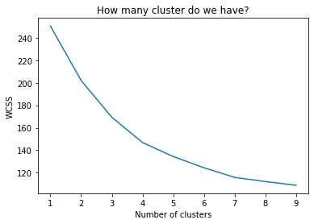

```python
# Using the elbow method to find the optimal number of clusters
from sklearn.cluster import KMeans
wcss = []
for i in range(1, 10):
    kmeans = KMeans(n_clusters = i, init = 'k-means++', random_state = 42)
    kmeans.fit(X)
    wcss.append(kmeans.inertia_)
plt.plot(range(1, 10), wcss)
plt.title('How many cluster do we have?')
plt.xlabel('Number of clusters')
plt.ylabel('WCSS')
plt.show()
```

Unfortunately, the graph above does not suggest any clear-cut conclusion about how many groups we should divide the data set into. Moving forward, we will arbitrarily set the number of clusters to be 3, instantiate a k mean object and fit it to the data set.

```python
# Fitting K-Means to the dataset
kmeans = KMeans(n_clusters = 3, init = 'k-means++', random_state = 42)
y_kmeans = kmeans.fit_predict(X)
```

#### Hierarchical Clustering

Next, we will apply Hierarchical Clustering to our dataset.  
Model Methodology  
Unlike the K Means algorithm, where we start by deciding the number of clusters to search for, Hierarchical Clustering starts from each data point and goes up. That is, for a dataset of N data points, we start with the trivial conclusion that the dataset forms N clusters. Next, we take the two closest clusters (still only two data points) and make them form a cluster, which revises our conclusion a little (we now have N – 1 clusters). Now, out of these N – 1 clusters, we merge the two closest clusters into one cluster. We now have N - 2 clusters. This process continues until there is only one cluster left. Repeating these steps naturally corresponds to forming a tree diagram from the bottom up. This tree diagram shows the history of our merging process. Using this tree diagram, we can observe the possible groupings of our data set by cutting the tree horizontally at an arbitrary height.  
Let us start the hierarching process and take a look at the tree diagram:

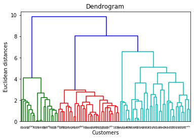

```python
# Using the dendrogram to find the optimal number of clusters
import scipy.cluster.hierarchy as sch
dendrogram = sch.dendrogram(sch.linkage(X, method = 'ward'))
plt.title('Dendrogram')
plt.xlabel('Customers')
plt.ylabel('Euclidean distances')
plt.show()
```

```python
# Fitting Hierarchical Clustering to the dataset
from sklearn.cluster import AgglomerativeClustering
hc = AgglomerativeClustering(n_clusters = 3, affinity = 'euclidean', linkage = 'ward')
y_hc = hc.fit_predict(X)
```

### Compare the Result

Having fitted the two models to the data set, we can now append the cluster labeling onto the original data set and see how the two models predict the categories:

```python
# Concatenate the prediction onto df
df['KM_pred'] = y_kmeans
df['HC_pred'] = y_hc
df[['CustID','KM_pred','HC_pred' ]]
```

|  | CustID | KM_pred | HC_pred |
| --- | --- | --- | --- |
| 0 | 1 | 1 | 1 |
| 1 | 198 | 2 | 0 |
| 2 | 260 | 2 | 0 |
| 3 | 1010 | 1 | 1 |
| 4 | 1017 | 0 | 2 |
| 5 | 1018 | 0 | 2 |
| 6 | 1021 | 0 | 2 |
| 7 | 1052 | 0 | 2 |
| 8 | 1054 | 1 | 1 |
| 9 | 1074 | 0 | 2 |
| 10 | 1095 | 1 | 1 |
| 11 | 1173 | 0 | 2 |
| 12 | 1205 | 0 | 2 |
| 13 | 1285 | 0 | 2 |
| 14 | 1287 | 1 | 1 |
| 15 | 1507 | 2 | 0 |
| 16 | 1563 | 2 | 0 |
| 17 | 1569 | 2 | 0 |
| 18 | 1585 | 2 | 0 |
| 19 | 1587 | 2 | 0 |
| 20 | 1596 | 2 | 0 |
| 21 | 1603 | 2 | 0 |
| 22 | 1628 | 2 | 0 |
| 23 | 1634 | 0 | 0 |
| 24 | 1653 | 2 | 0 |
| 25 | 1654 | 1 | 1 |
| 26 | 1655 | 2 | 0 |
| 27 | 1661 | 2 | 0 |
| 28 | 1675 | 1 | 1 |
| 29 | 1692 | 2 | 0 |

[output cut: 61 more lines]

### Behavioral Characteristics of Each Group

Next, we will divide the customers into three different groups according to the results from our K-means model. Then we examine each group to find its behavioral tendencies. We group each cluster together and take the mean value of each cell. Since the top 3 customers have a tremendous impact on the mean value of entities, we will exclude those three customers from our analysis moving forward. I should note that although the rest of the customers have relatively similar impacts on the mean values, each customer's individual behavior varries greatly compared to the other customers, which makes it somewhat harder for the three groups to represent their members' individual characteristics.  
The data after grouping is shown below:

```python
# Remove top three customers from the data set
for custid in top_custid:
    df = df.loc[df.CustID != custid]

# Group the data by the K Mean label
grouped_km =  df.groupby('KM_pred')
groups = [grouped_km.mean().iloc[i,1:-1] for i in range(len(grouped_km))]
df_group = pd.DataFrame(groups)
df_group
```

|  | TCount | 20200301 | 20200302 | 20200303 | 20200304 | 20200305 | 20200306 | 20200307 | 20200308 | 20200309 | 20200310 | 20200311 | 20200312 | 20200313 | 20200314 | 20200315 | 20200316 | 20200317 | 20200318 | 20200319 | 20200320 | 20200321 | 20200322 | 20200323 | 20200324 | 20200325 | 20200326 | 20200327 | 20200328 | … |
| --- | --- | --- | --- | --- | --- | --- | --- | --- | --- | --- | --- | --- | --- | --- | --- | --- | --- | --- | --- | --- | --- | --- | --- | --- | --- | --- | --- | --- | --- | --- |
| 0 | 57.470588 | 85.058824 | 129.235294 | 128.764706 | 130.323529 | 129.411765 | 129.323529 | 127.323529 | 127.029412 | 129.676471 | 130.029412 | 128.882353 | 128.294118 | 127.852941 | 127.176471 | 127.058824 | 129.088235 | 128.147059 | 127.382353 | 128.029412 | 128.264706 | 127.147059 | 127.000000 | 128.352941 | 128.470588 | 128.088235 | 129.294118 | 128.029412 | 127.176471 | … |
| 1 | 71700.600000 | 165.200000 | 7329.300000 | 6039.450000 | 2543.750000 | 367.550000 | 2882.600000 | 243.100000 | 245.250000 | 9760.950000 | 7479.900000 | 3225.600000 | 3224.300000 | 459.650000 | 236.700000 | 234.700000 | 3414.300000 | 1737.400000 | 2877.500000 | 3074.450000 | 611.450000 | 248.500000 | 239.600000 | 16182.750000 | 1310.450000 | 11792.500000 | 371.250000 | 4033.650000 | 246.900000 | … |
| 2 | 33958.558824 | 700.000000 | 3104.676471 | 2231.441176 | 2426.529412 | 1115.882353 | 963.735294 | 1112.088235 | 590.588235 | 980.735294 | 876.382353 | 935.058824 | 835.441176 | 864.970588 | 638.235294 | 634.000000 | 1018.823529 | 942.735294 | 893.705882 | 1191.323529 | 1030.147059 | 698.911765 | 500.352941 | 1033.558824 | 909.852941 | 939.705882 | 1517.588235 | 5247.911765 | 860.764706 | … |

Finally, we examine the characteristics of each group by observing the histograms and bar plots of each category (i.e. Date, Day, TFound, TType and TDetail). Again, it is very important to note that we should be cautious in describing the tendency of each group; although we took the mean of each value, we should keep in mind that each customer has its own very skewed behavior.

#### Group A

Here are the customers labeled as 0. We'll call them Group A:

```python
df.loc[df.KM_pred == 0][['CustID', 'KM_pred']]
```

|  | CustID | KM_pred |
| --- | --- | --- |
| 4 | 1017 | 0 |
| 5 | 1018 | 0 |
| 6 | 1021 | 0 |
| 7 | 1052 | 0 |
| 9 | 1074 | 0 |
| 11 | 1173 | 0 |
| 12 | 1205 | 0 |
| 13 | 1285 | 0 |
| 23 | 1634 | 0 |
| 32 | 1749 | 0 |
| 38 | 1885 | 0 |
| 40 | 1923 | 0 |
| 43 | 1966 | 0 |
| 47 | 2046 | 0 |
| 58 | 2197 | 0 |
| 62 | 2245 | 0 |
| 63 | 2256 | 0 |
| 65 | 2282 | 0 |
| 66 | 2310 | 0 |
| 67 | 2343 | 0 |
| 68 | 2362 | 0 |
| 69 | 2382 | 0 |
| 70 | 2405 | 0 |
| 73 | 2481 | 0 |
| 75 | 2498 | 0 |
| 76 | 2507 | 0 |
| 79 | 2537 | 0 |
| 80 | 2574 | 0 |
| 81 | 2588 | 0 |
| 82 | 2593 | 0 |
| 83 | 2623 | 0 |
| 84 | 2633 | 0 |
| 87 | 2680 | 0 |
| 88 | 2684 | 0 |

Let's look at the behavior of each category for Group A:

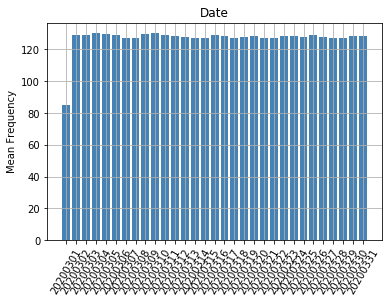

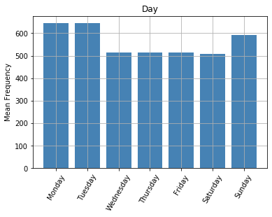

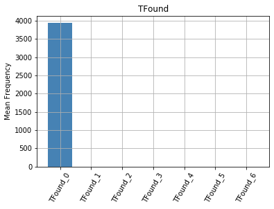

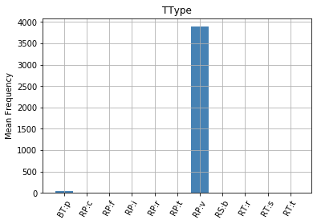

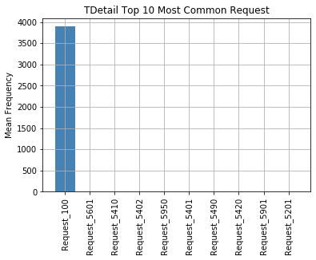

```python
# Define categories to look at
categories = {'Date': list(df_group.columns[1:32]), 'Day': list(df_group.columns[32:39]),
              'TFound':list(df_group.columns[39:46]), 'TType': list(df_group.columns[46:57]),
             'TDetail' : list(df_group.columns[57:-2]) }

i = 0
# For each category, plot bar graph for each group
for name in categories:
    if name != 'TDetail':
        plt.bar(categories[name],
                df_group.loc[i,categories[name]].values,
                color='steelblue')
        plt.xticks(rotation=60)
        plt.ylabel('Mean Frequency')
        plt.title(name)
        plt.grid(True)
        plt.show()
    else:
        row = df_group.loc[i,categories[name]]
        row = row.sort_values(ascending=False)
        plt.bar(row.index[0:10],row.values[0:10],color='steelblue')
        plt.title(name + str(' Top 10 Most Common Request'))
        plt.xticks(rotation=90)
        plt.ylabel('Mean Frequency')
        plt.grid(True)
        plt.show()
```

Group A shows the following patterns:

- The number of transaction requests is consistently low throughout the month (or week) compared to the other two groups.
- All the transactions are unknown (TFound = 0)
- Most of the transaction types are RP:V
- All the transaction requests are Request_100

#### Group B

```python
df.loc[df.KM_pred == 1][['CustID', 'KM_pred']]
```

|  | CustID | KM_pred |
| --- | --- | --- |
| 0 | 1 | 1 |
| 3 | 1010 | 1 |
| 8 | 1054 | 1 |
| 10 | 1095 | 1 |
| 14 | 1287 | 1 |
| 25 | 1654 | 1 |
| 28 | 1675 | 1 |
| 30 | 1717 | 1 |
| 35 | 1768 | 1 |
| 57 | 2187 | 1 |
| 64 | 2276 | 1 |
| 71 | 2413 | 1 |
| 72 | 2424 | 1 |
| 74 | 2493 | 1 |
| 77 | 2509 | 1 |
| 78 | 2520 | 1 |
| 85 | 2662 | 1 |
| 86 | 2669 | 1 |
| 89 | 2704 | 1 |
| 90 | 2707 | 1 |

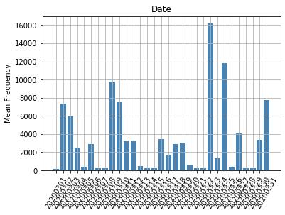

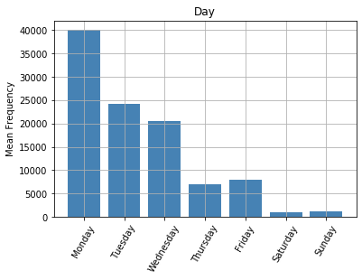

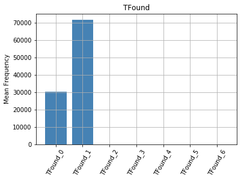

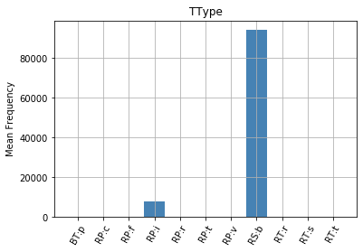

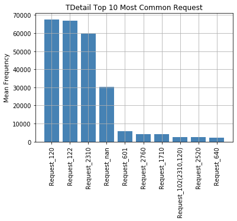

```python
i = 1
# For each category, plot bar graph for each group
for name in categories:
    if name != 'TDetail':
        plt.bar(categories[name],
                df_group.loc[i,categories[name]].values,
                color='steelblue')
        plt.xticks(rotation=60)
        plt.ylabel('Mean Frequency')
        plt.title(name)
        plt.grid(True)
        plt.show()
    else:
        row = df_group.loc[i,categories[name]]
        row = row.sort_values(ascending=False)
        plt.bar(row.index[0:10],row.values[0:10],color='steelblue')
        plt.title(name + str(' Top 10 Most Common Request'))
        plt.xticks(rotation=90)
        plt.ylabel('Mean Frequency')
        plt.grid(True)
        plt.show()
```

Group B has the following patterns: